# Applied Modelling in Drug Development

## Model Comparison

```r
loo_compare(fit_long_lin_vs, fit_long_mo)
```

```
                elpd_diff se_diff
fit_long_mo       0.0       0.0
fit_long_lin_vs -91.5      11.7
```

## Longitudinal Data: Quadratic Model

```r
fit_long_quad <- brm(
  CHG ~ BASE + TRT01P * (AVISITN + I(AVISITN^2)) +
    (1 + AVISITN + I(AVISITN^2) | SUBJID),
  data = pasi_data, seed = 245124
)
fit_long_quad <- add_criterion(fit_long_quad, "loo")
```

Total elapsed fitting time:

```r
sum(rstan::get_elapsed_time(fit_long_quad$fit))
```

```
[1] 43.367
```

## Quadratic Model: Visualization of effects

```r
conditional_effects(fit_long_quad, "AVISITN:TRT01P")
```

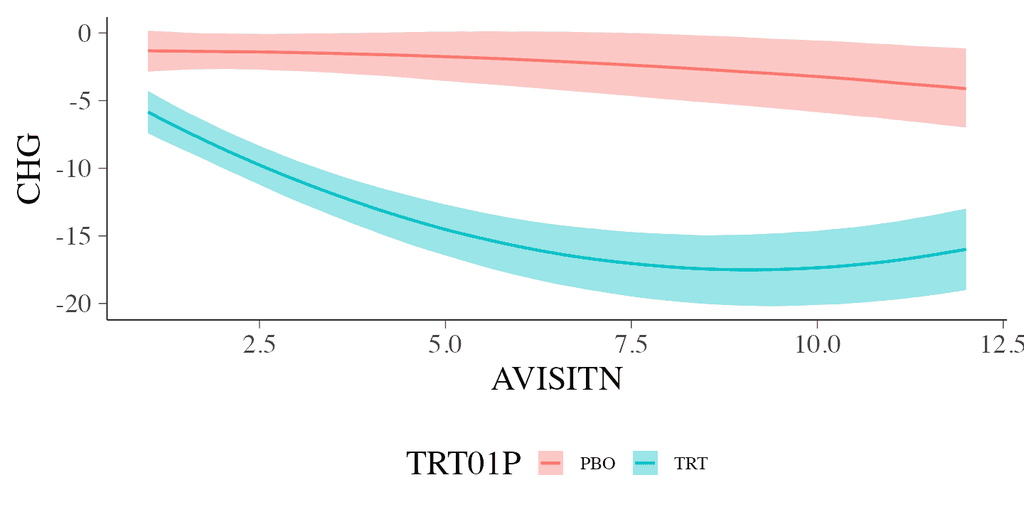

## Longitudinal Data: Centering the time variable

Non-centered variables are often highly correlated with their square

```r
cor(pasi_data$AVISITN, pasi_data$AVISITN^2)
```

```
[1] 0.9734303
```

Centering can be done around any central value. Here we use 6 because this is the average week in the study

```r
pasi_data <- pasi_data |>
  mutate(AVISITN_c = AVISITN - 6)
```

After centering, the correlation is drastically reduced

```r
cor(pasi_data$AVISITN_c, pasi_data$AVISITN_c^2)
```

```
[1] 0.2548532
```

## Longitudinal Data: Centered Quadratic model

```r
fit_long_quad_c <- brm(
  CHG ~ BASE + TRT01P * (AVISITN_c + I(AVISITN_c^2)) +
    (1 + AVISITN_c + I(AVISITN_c^2) | SUBJID),
  data = pasi_data, seed = 24547
)
fit_long_quad_c <- add_criterion(fit_long_quad_c, "loo")
```

Total elapsed fitting time:

```r
sum(rstan::get_elapsed_time(fit_long_quad_c$fit))
```

```
[1] 15.844
```

## Centered Quadratic Model: Visualization of effects

```r
conditional_effects(fit_long_quad_c, "AVISITN_c:TRT01P")
```

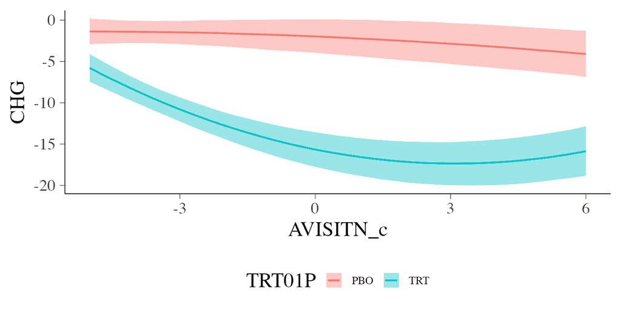

## Model Comparison

```r
loo_compare(fit_long_mo, fit_long_quad_c)
```

```
                elpd_diff se_diff
fit_long_mo       0.0       0.0
fit_long_quad_c -17.8       9.8
```

## Longitudinal Data: Gaussian Process Model

```r
fit_long_gp <- brm(
  CHG ~ BASE + gp(AVISITN_c, by = TRT01P, k=9) +
    (1 + (AVISITN_c + I(AVISITN_c^2)) | SUBJID),
  data = pasi_data, seed = 32454,
  control = list(adapt_delta = 0.95)
)
fit_long_gp <- add_criterion(fit_long_gp, "loo")
```

Total elapsed fitting time:

```r
sum(rstan::get_elapsed_time(fit_long_gp$fit))
```

```
[1] 1382.061
```

## Gaussian Process Model: LOO-CV results

```r
loo(fit_long_gp)
```

```
Computed from 4000 by 684 log-likelihood matrix.

         Estimate   SE
elpd_loo  -2042.9 35.3
p_loo       191.4 15.6
looic      4085.9 70.7
------
MCSE of elpd_loo is NA.
MCSE and ESS estimates assume MCMC draws (r_eff in [0.3, 1.7]).

Pareto k diagnostic values:
                         Count Pct.    Min. ESS
(-Inf, 0.7]   (good)     643   94.0%   121
   (0.7, 1]   (bad)       36    5.3%   <NA>
   (1, Inf)   (very bad)   5    0.7%   <NA>
See help('pareto-k-diagnostic') for details.
```

## Gaussian Process Model: Visualization of effects

```r
conditional_effects(fit_long_gp, "AVISITN_c:TRT01P")
```

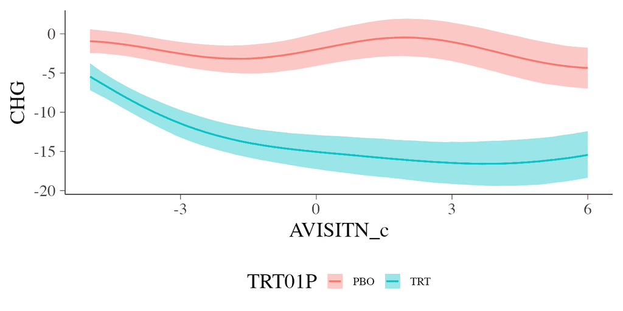

## Model Comparison

```r
loo_compare(fit_long_quad_c, fit_long_gp)
```

```
                elpd_diff se_diff
fit_long_gp       0.0       0.0
fit_long_quad_c -13.9       6.3
```

Recall that model comparisons may not be trustworthy.

## Longitudinal Data: Gaussian Process AR1 Model

```r
fit_long_gp_ar <- brm(
  CHG ~ BASE + gp(AVISITN_c, by = TRT01P, k=9) +
    ar(AVISITN_c, gr = SUBJID, p = 1) +
    (1 + (AVISITN_c + I(AVISITN_c^2)) | SUBJID),
  data = pasi_data, seed = 24235,
  iter = 4000, warmup = 1000,
  control = list(adapt_delta = 0.95)
)
fit_long_gp_ar <- add_criterion(fit_long_gp_ar, "loo")
```

Total elapsed fitting time:

```r
sum(rstan::get_elapsed_time(fit_long_gp_ar$fit))
```

```
[1] 183.181
```

## Gaussian Process AR1 Model: Autocorrelation results

Some autocorrelation may be present:

```r
posterior_summary(fit_long_gp_ar, variable = "ar") |>
  round(3)
```

```
      Estimate Est.Error  Q2.5 Q97.5
ar[1]    0.384     0.122 0.159  0.63
```

A more formal model comparison may be theoretically advantageous but given that we add only a single parameter (the AR1 effect), we should probably gain more than we loose by including it.

## Gaussian Process AR1 Model: Visualization of effects

```r
conditional_effects(fit_long_gp_ar, "AVISITN_c:TRT01P")
```

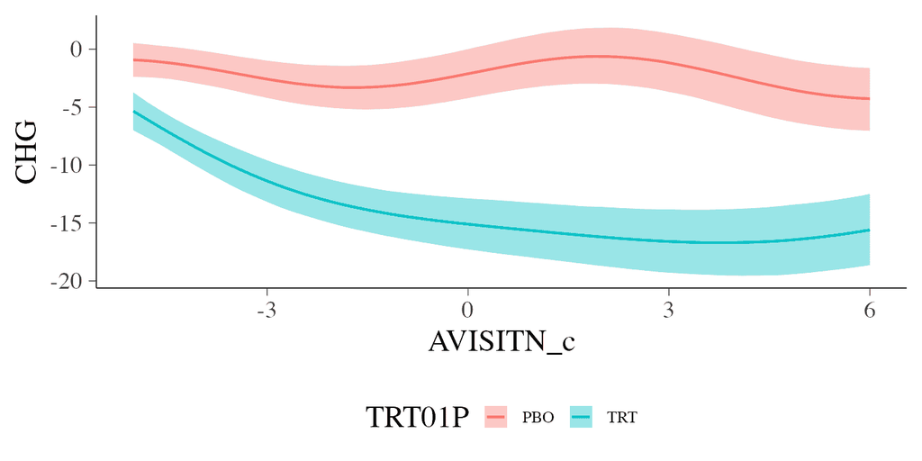

# Time-to-Event analysis

## Overview and Analysis Goals

- Oncology late phase trial to evaluate efficacy of an active drug given in addition to two similar standard of care (SoC-A and SoC-B), which vary geographically
- A total of 4 trial arms studied combining
  - SoC-A & active vs SoC-A
  - SoC-B & active vs SoC-B
- Analysis needs to account for:
  - SoC-A and SoC-B are known for similar efficacy
  - Active drug efficacy is expected to be consistent with SoC-A and SoC-B  
    $\Rightarrow$ interest in average treatment effect

> Key analysis goal: Reflect prior knowledge on similarity and increase efficiency in estimating average treatment effect $\Rightarrow$ control model *parametrization*.

## Simulated Data Set

First few rows of the simulated dataset:

|  | y | event | trt | soc | arm |
| --- | --- | --- | --- | --- | --- |
| 1 | 7.70 | 0 | ctl | ChA | ctlChA |
| 2 | 0.10 | 0 | act | ChA | actChA |
| 3 | 4.75 | 0 | ctl | ChA | ctlChA |
| 4 | 2.75 | 0 | act | ChA | actChA |
| 5 | 3.61 | 1 | ctl | ChA | ctlChA |
| 6 | 0.94 | 1 | act | ChA | actChA |
| 7 | 0.26 | 1 | ctl | ChA | ctlChA |
| 8 | 9.21 | 1 | act | ChA | actChA |
| 9..199 |  |  |  |  |  |
| 200 | 11.81 | 0 | act | ChA | actChA |

## Contrasts Define Model Parametrization

Overall mean (intercept):
$$\mu = \frac{1}{4}( \mu_{actChA} + \mu_{ctlChA} + \mu_{actChB} + \mu_{ctlChB} )$$

Average difference between the active and control arms:
$$\delta_{avg.diff} = \frac{1}{2} ( [\mu_{actChA} - \mu_{ctlChA}] + [ \mu_{actChB} - \mu_{ctlChB}] )$$

Half of the difference in treatment effect between the two SOC:
$$\delta_{effect} = \frac{1}{2}( [ \mu_{actChA} - \mu_{ctlChA}] - [ \mu_{actChB} - \mu_{ctlChB}] )$$

Difference between the two control arms:
$$\delta_{control} = - \mu_{ctlChA} + \mu_{ctlChB}$$

## Contrasts Defined Via Inverse Mapping

First specify the groups as a function of the contrasts:

```r
cc_inv
```

```
              arm
contrast       actChA ctlChA actChB ctlChB
  intercept     1/4    1/4    1/4    1/4
  effectAvg     1/2   -1/2    1/2   -1/2
  deltaEffect   1/2   -1/2   -1/2    1/2
  deltaControl    0     -1      0      1
```

## Contrasts: Contrast Matrix

Then invert the matrix to get the actual contrast matrix:

```r
cc <- solve(cc_inv)
```

```
       intercept effectAvg deltaEffect deltaControl
actChA    1       1/2         1        -1/2
ctlChA    1      -1/2         0        -1/2
actChB    1       1/2        -1         1/2
ctlChB    1      -1/2         0         1/2
```

To use the custom contrasts, we have to assign these to the respective `factor` column of the data (but exclude the overall intercept):

```r
contrasts(sim$arm) <- cc[, -1]
```

## The Weibull Family in `brms`

When using family `weibull` in brms, we are modeling the mean time $\mu$ until the event, **not** the hazard function!

Parameterize as mean time $\mu$ and shape $\alpha$ such that, with scale $s = \mu / \Gamma(1 + \frac{1}{\alpha})$:

$$\text{Weibull}(t) = \frac{\alpha}{s} \left( \frac{t}{s}
\right)^{\alpha-1} \, \exp\left(-\left(\frac{t}{s}\right)^\alpha\right)$$

- This is an accelerated failure time model since the survivor function has the property of $S_i(t) = S_{\text{weibull}}(t/\mu_i)$.
- When using a log linear model on $\mu$
  - the intercept is the $\log$-mean event time
  - regression coefficients are interpretable as speedup/slowdown of the process

> See the [brms vignette online on families](https://paulbuerkner.com/brms/articles/brms_families.html) for family parametrization details.

## Specify `brms` Weibull Model

```r
model_weibull1 <- bf(y | cens(1-event) ~ 1 + arm,
                     family=weibull())

prior_weibull1 <-
  prior(normal(meanInter, log(4)/1.64), class="Intercept") +
  prior(normal(0, sdEffect), coef=armeffectAvg) +
  prior(normal(0, sdDeltaEffect), coef=armdeltaEffect) +
  prior(normal(0, sdDeltaControl), coef=armdeltaControl) +
  prior(gamma(0.1, 0.1), class=shape)
```

We use variable symbols like `meanInter`, `sdEffect` and the like, which need to be defined with `stanvars`,

```r
stanvars_weibull1 <-
  stanvar(-log(log(2)/8), name = "meanInter") +
  stanvar(log(2)/1.64, name = "sdEffect") +
  stanvar(log(1.25)/1.64, name = "sdDeltaEffect") +
  stanvar(log(1.25)/1.64, name = "sdDeltaControl")
```

This avoids model recompilation when changing priors.

## Fit `brms` Weibull Model

```r
fit_weibull1 <- brm(
  formula = model_weibull1,
  data = sim,
  prior = weibull_prior1,
  stanvars = stanvars_weibull1,
  seed=345665
)
```

## Model Summary

```r
summary(fit_weibull1)
```

```
 Family: weibull
  Links: mu = log
Formula: y | cens(1 - event) ~ 1 + arm
   Data: sim (Number of observations: 200)

Regression Coefficients:
                Estimate Est.Error l-95% CI u-95% CI Rhat Bulk_ESS Tail_ESS
Intercept           2.16      0.12     1.95     2.41 1.00     3672     2803
armeffectAvg        0.26      0.18    -0.10     0.61 1.00     4707     2934
armdeltaEffect      0.01      0.11    -0.20     0.21 1.00     4316     2583
armdeltaControl     0.06      0.12    -0.18     0.30 1.00     4717     2917

Further Distributional Parameters:
      Estimate Est.Error l-95% CI u-95% CI Rhat Bulk_ESS Tail_ESS
shape     0.97      0.08     0.83     1.13 1.00     3243     2880
```

## Posterior Predictive Checks

```r
pp_check(
  fit_weibull1, type = "km_overlay",
  ndraws = 100
)
```

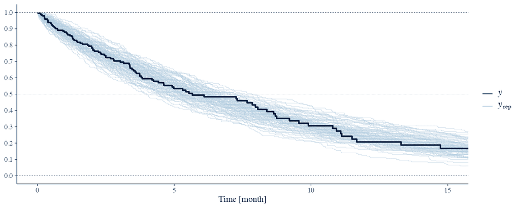

The model predictions assume no censoring

## Including Historical Data

Suppose we have historical data available from a previous study where only SoC was applied. This extends our control group data:

|  | y | event | arm | hist1 |
| --- | --- | --- | --- | --- |
| 1 | 3.64 | 1 | ctlChA | 1 |
| 2 | 8.39 | 1 | ctlChA | 1 |
| 3 | 6.46 | 0 | ctlChA | 1 |
| 4 | 3.18 | 1 | ctlChA | 1 |
| 5 | 1.29 | 1 | ctlChA | 1 |
| 6 | 5.90 | 0 | ctlChA | 1 |
| 7 | 1.99 | 0 | ctlChA | 1 |
| 8 | 2.66 | 1 | ctlChA | 1 |
| 9..399 |  |  |  |  |
| 400 | 1.03 | 1 | ctlChA | 1 |

## Including Historical Data: Analysis Code

- Approximation of a meta-analytic-approach (MAP) by allowing a deviation for the historical data set on the overall intercept through an indicator covariate
- Use of a heavy tailed Student-t prior resembles heavy-tailed MAP random effect

```r
sim_comb <- bind_rows(sim, hdata1)
contrasts(sim_comb$arm) <- cc[, -1]

model_weibull2 <- bf(
  y | cens(1-event) ~ 1 + arm + hist1,
  family=weibull()
)

prior_weibull2 <- prior_weibull1 +
  prior(student_t(6, 0, sdHist), coef = hist1)

stanvars_weibull2 <- stanvars_weibull1 +
  stanvar(log(1.8)/1.64, name = "sdHist")
```

```r
fit_weibull2 <- brm(
  formula = model_weibull2,
  data = sim_comb,
  prior = weibull_prior2,
  stanvars = stanvars_weibull2,
  seed=4567886
)
```

## Summarize the Model

```r
summary(fit_weibull2)
```

```
 Family: weibull
  Links: mu = log
Formula: y | cens(1 - event) ~ 1 + arm + hist1
   Data: sim_comb (Number of observations: 600)

Regression Coefficients:
                Estimate Est.Error l-95% CI u-95% CI Rhat Bulk_ESS Tail_ESS
Intercept           2.12      0.10     1.92     2.32 1.00     4702     3700
armeffectAvg        0.28      0.17    -0.05     0.62 1.00     3852     2852
armdeltaEffect      0.01      0.10    -0.20     0.21 1.00     5305     3165
armdeltaControl     0.07      0.12    -0.17     0.30 1.00     5035     3240
hist1              -0.20      0.14    -0.48     0.06 1.00     3765     2906

Further Distributional Parameters:
      Estimate Est.Error l-95% CI u-95% CI Rhat Bulk_ESS Tail_ESS
shape     1.00      0.04     0.92     1.08 1.00     4607     3043
```

## Time-to-Event Modelling: Outlook

In the [online case study](https://opensource.nibr.com/bamdd) you additionally find:

- Additional details and model justification based on a real dataset
- Include historical data of a trial reporting on the *average* effect of SoC-A and SoC-B
- Add custom coded contrasts to further improve flexibility of historical data analysis

# Course wrap-up

## Summary

- Diverse opportunities for applied modelling to inform good drug-development decisions
- Bayesian paradigm is well suited for many of these situations
  - Availability of meaningful prior information
  - Desire for probabilistically interpretable statements about unknowns and future observable quantities
- `brms` is a powerful and highly flexible engine for applied modelling , facilitating straightforward model specification and inference

## Looking ahead

- We hope you have:
  - Become familiar with `brms` syntax and workflow
  - Seen its versatility for statistical modelling in drug development
  - Gained hands-on experience with the package from guided exercises
- And that you feel empowered to use `brms` going forward!

## Resources

- Our open-source book:  
  [Bayesian Applied Modelling in Drug Developoment (BAMDD)](https://opensource.nibr.com/bamdd)
- [Course materials on GitHub](https://github.com/Novartis/bamdd/tree/main/workshops/graz2025)
- `brms` documentation: https://paul-buerkner.github.io/brms/
- Stan homepage: https://mc-stan.org
- Stan forums: https://discourse.mc-stan.org

## Thank you

- Thank you for your interest and participation!
- Our contact information:
  - Sebastian: sebastian.weber@novartis.com
  - Lukas: lukas_andreas.widmer@novartis.com